# 012 Saddle Point issue of Neural Netoworks

### Visualizing and Demonstrating a Saddle Point

The problem of **saddle points** is a significant challenge in optimizing neural networks (and other complex functions). In high-dimensional spaces, saddle points are far more common than local minima.

A saddle point is a point where the gradient of the function is zero (or very close to zero), making it a critical point, but it is **neither a local minimum nor a local maximum**. If you move in one direction from a saddle point, the function value might increase, but if you move in another direction, it will decrease. This creates a "saddle" or "mountain pass" shape.

**Why are they a problem for optimization?**

- **Zero Gradient:** Because the gradient is zero (or very small) at a saddle point, optimization algorithms like Gradient Descent (GD) can get "stuck" or significantly slow down. GD relies on the gradient to know which way to move downhill.
- **Slow Escape:** Even if an optimizer eventually moves away, the region around a saddle point can be very flat, meaning the gradient remains small for a significant distance. This makes progress extremely slow.
- **High-Dimensional Space:** In very high-dimensional loss landscapes (like those of deep neural networks), most critical points are saddle points, not local minima. This means optimizers frequently encounter them.

```python
import numpy as np
import matplotlib.pyplot as plt
from mpl_toolkits.mplot3d import Axes3D

# --- 1. Define the Saddle Point Function and its Gradient ---
def saddle_function(x, y):
    """f(x, y) = x^2 - y^2"""
    return x**2 - y**2

def saddle_gradient(x, y):
    """Gradient of f(x, y) = (df/dx, df/dy) = (2x, -2y)"""
    df_dx = 2 * x
    df_dy = -2 * y
    return np.array([df_dx, df_dy])
```

```python
# --- 2. Implement Gradient Descent ---
def gradient_descent(start_point, learning_rate, iterations, function_gradient):
    """
    Performs gradient descent on a 2D function.
    Returns a list of points (trajectory) and corresponding function values.
    """
    path = [np.array(start_point)]
    values = [saddle_function(start_point[0], start_point[1])]

    for i in range(iterations):
        current_x, current_y = path[-1]
        grad_x, grad_y = function_gradient(current_x, current_y)

        # Update rule: point = point - learning_rate * gradient
        new_x = current_x - learning_rate * grad_x
        new_y = current_y - learning_rate * grad_y

        new_point = np.array([new_x, new_y])
        path.append(new_point)
        values.append(saddle_function(new_x, new_y))

        # Stop if numerical instability (very large values) occurs
        if np.any(np.abs(new_point) > 1e10):
            print(f"Warning: Gradient exploded at iteration {i+1}. Stopping.")
            break

    return np.array(path), np.array(values)
```

```python
# --- 3. Visualization Setup ---
x = np.linspace(-3, 3, 100)
y = np.linspace(-3, 3, 100)
X, Y = np.meshgrid(x, y)
Z = saddle_function(X, Y)
```

```python
# --- 4. Run Gradient Descent from Different Starting Points ---
learning_rate = 0.05
iterations = 200

# Scenario 1: Starting very close to the saddle point
start_point_1 = [0.01, 0.01] # Slightly off (0,0)
path1, values1 = gradient_descent(start_point_1, learning_rate, iterations, saddle_gradient)

# Scenario 2: Starting exactly on the saddle point (ideally no movement)
start_point_2 = [0.0, 0.0]
path2, values2 = gradient_descent(start_point_2, learning_rate, iterations, saddle_gradient)

# Scenario 3: Starting slightly off, but with one coordinate far from zero
start_point_3 = [0.01, 2.0] # Far in Y, close in X
path3, values3 = gradient_descent(start_point_3, learning_rate, iterations, saddle_gradient)

# Scenario 4: Starting slightly off, but with noise added at each step (simulating SGD or noise)
def gradient_descent_with_noise(start_point, learning_rate, iterations, function_gradient, noise_scale=0.01):
    path = [np.array(start_point)]
    values = [saddle_function(start_point[0], start_point[1])]

    for i in range(iterations):
        current_x, current_y = path[-1]
        grad_x, grad_y = function_gradient(current_x, current_y)

        # Add random noise to the gradient
        grad_x += np.random.normal(0, noise_scale)
        grad_y += np.random.normal(0, noise_scale)

        new_x = current_x - learning_rate * grad_x
        new_y = current_y - learning_rate * grad_y

        new_point = np.array([new_x, new_y])
        path.append(new_point)
        values.append(saddle_function(new_x, new_y))
        if np.any(np.abs(new_point) > 1e10):
            break
    return np.array(path), np.array(values)

start_point_4 = [0.01, 0.01] # Same as scenario 1
path4, values4 = gradient_descent_with_noise(start_point_4, learning_rate, iterations, saddle_gradient, noise_scale=0.05)
```

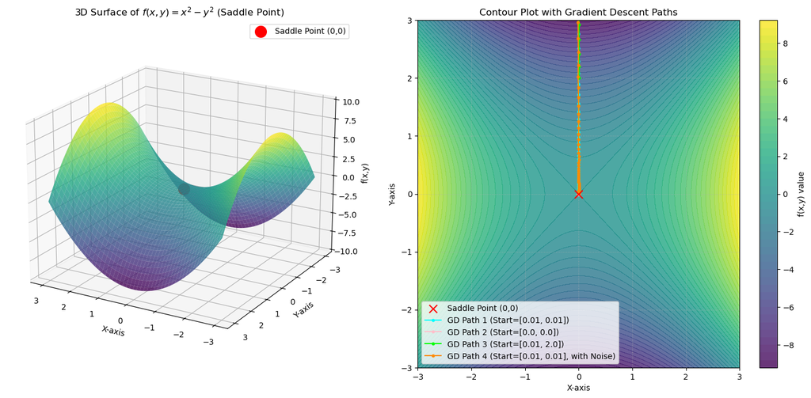

```python
# --- 5. Plotting ---

# 3D Surface Plot
fig = plt.figure(figsize=(15, 7))
ax1 = fig.add_subplot(121, projection='3d')
ax1.plot_surface(X, Y, Z, cmap='viridis', alpha=0.8, edgecolor='none')
ax1.scatter([0], [0], [saddle_function(0,0)], color='red', s=200, label='Saddle Point (0,0)', depthshade=False, zorder=5) # Mark saddle point

ax1.set_xlabel('X-axis')
ax1.set_ylabel('Y-axis')
ax1.set_zlabel('f(x,y)')
ax1.set_title('3D Surface of $f(x,y) = x^2 - y^2$ (Saddle Point)')
ax1.legend()
ax1.view_init(elev=20, azim=120) # Adjust view for better perspective

# Contour Plot with Optimization Paths
ax2 = fig.add_subplot(122)
contour = ax2.contourf(X, Y, Z, levels=50, cmap='viridis', alpha=0.8)
fig.colorbar(contour, ax=ax2, label='f(x,y) value')
ax2.scatter(0, 0, color='red', marker='x', s=100, label='Saddle Point (0,0)', zorder=5)

ax2.plot(path1[:, 0], path1[:, 1], color='cyan', linestyle='-', marker='o', markersize=3, label=f'GD Path 1 (Start={start_point_1})')
ax2.plot(path2[:, 0], path2[:, 1], color='pink', linestyle='-', marker='o', markersize=3, label=f'GD Path 2 (Start={start_point_2})')
ax2.plot(path3[:, 0], path3[:, 1], color='lime', linestyle='-', marker='o', markersize=3, label=f'GD Path 3 (Start={start_point_3})')
ax2.plot(path4[:, 0], path4[:, 1], color='darkorange', linestyle='-', marker='o', markersize=3, label=f'GD Path 4 (Start={start_point_4}, with Noise)')

ax2.set_xlabel('X-axis')
ax2.set_ylabel('Y-axis')
ax2.set_title('Contour Plot with Gradient Descent Paths')
ax2.legend(loc='lower left')
ax2.grid(True, linestyle=':', alpha=0.6)
ax2.set_xlim([-3, 3])
ax2.set_ylim([-3, 3])

plt.tight_layout()
plt.show()
```